# Prediction of Success/Failure of crowdfunding Projects (Part A)

### Author: Yan Chen

```python
import numpy as np
import pandas as pd
import sklearn
import matplotlib.pyplot as plt
from sklearn import preprocessing
from sklearn.feature_extraction.text import CountVectorizer
from sklearn.utils import shuffle

import re
import nltk

from bs4 import BeautifulSoup
from nltk.corpus import stopwords
from nltk.stem.porter import PorterStemmer
english_stemmer=nltk.stem.SnowballStemmer('english')

from sklearn.feature_selection.univariate_selection import SelectKBest, chi2, f_classif
from sklearn.model_selection import train_test_split
from sklearn.feature_extraction.text import TfidfVectorizer
from sklearn.linear_model import SGDClassifier, SGDRegressor
from sklearn.ensemble import RandomForestClassifier, GradientBoostingClassifier
from sklearn.naive_bayes import MultinomialNB
from sklearn.metrics import accuracy_score, classification_report, confusion_matrix
import random
import itertools

import sys
import os
import argparse
from sklearn.pipeline import Pipeline
from scipy.sparse import csr_matrix
from sklearn.feature_extraction.text import CountVectorizer
import six
from abc import ABCMeta
from scipy import sparse
from scipy.sparse import issparse
from sklearn.base import BaseEstimator, ClassifierMixin
from sklearn.utils import check_X_y, check_array
from sklearn.utils.extmath import safe_sparse_dot
from sklearn.preprocessing import normalize, binarize, LabelBinarizer
from sklearn.svm import LinearSVC

from keras.preprocessing import sequence
from keras.utils import np_utils
from keras.models import Sequential
from keras.layers.core import Dense, Dropout, Activation, Lambda
from keras.layers.embeddings import Embedding
from keras.layers.recurrent import LSTM, SimpleRNN, GRU
from keras.preprocessing.text import Tokenizer
from collections import defaultdict
from keras.layers.convolutional import Convolution1D
from keras import backend as K

import seaborn as sns
from matplotlib import cm
%matplotlib inline
plt.style.use('ggplot')

import random
random.seed(1)
```

```python
df = pd.read_csv('train.csv')
```

```python
# count the number of successful projects and failed projects
succ_num = sum(df['final_status'] == 1)
print(succ_num)
total_num = df.shape[0]
print(total_num)
print(1- succ_num/total_num)
```

```
34561
108129
0.6803725180108944
```

# 1. Data Preprocessing (Part 1)

Now we do some text transform of keywords data and try to get some insight.

```python
df.info() #description of the data
```

```
<class 'pandas.core.frame.DataFrame'>
RangeIndex: 108129 entries, 0 to 108128
Data columns (total 14 columns):
project_id               108129 non-null object
name                     108126 non-null object
desc                     108120 non-null object
goal                     108129 non-null float64
keywords                 108129 non-null object
disable_communication    108129 non-null bool
country                  108129 non-null object
currency                 108129 non-null object
deadline                 108129 non-null int64
state_changed_at         108129 non-null int64
created_at               108129 non-null int64
launched_at              108129 non-null int64
backers_count            108129 non-null int64
final_status             108129 non-null int64
dtypes: bool(1), float64(1), int64(6), object(6)
memory usage: 10.8+ MB
```

**So we can see that 'name' and 'desc' columns have missing values, but there are only 3 and 9 of them respectively. So we just choose to drop these rows.**

```python
data=df.dropna(inplace=False)
data.shape
```

```
(108119, 14)
```

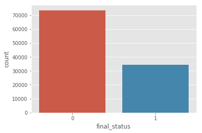

```python
sns.countplot(data['final_status'])
```

About 30% successful projects, 70% failed projects.

```python
data.head()
```

|  | project_id | name | desc | goal | keywords | disable_communication | country | currency | deadline | state_changed_at | created_at | launched_at | backers_count | final_status |
| --- | --- | --- | --- | --- | --- | --- | --- | --- | --- | --- | --- | --- | --- | --- |
| 0 | kkst1451568084 | drawing for dollars | I like drawing pictures. and then i color them... | 20.0 | drawing-for-dollars | False | US | USD | 1241333999 | 1241334017 | 1240600507 | 1240602723 | 3 | 1 |
| 1 | kkst1474482071 | Sponsor Dereck Blackburn (Lostwars) Artist in ... | I, Dereck Blackburn will be taking upon an inc... | 300.0 | sponsor-dereck-blackburn-lostwars-artist-in-re... | False | US | USD | 1242429000 | 1242432018 | 1240960224 | 1240975592 | 2 | 0 |
| 2 | kkst183622197 | Mr. Squiggles | So I saw darkpony's successfully funded drawin... | 30.0 | mr-squiggles | False | US | USD | 1243027560 | 1243027818 | 1242163613 | 1242164398 | 0 | 0 |
| 3 | kkst597742710 | Help me write my second novel. | Do your part to help out starving artists and ... | 500.0 | help-me-write-my-second-novel | False | US | USD | 1243555740 | 1243556121 | 1240963795 | 1240966730 | 18 | 1 |
| 4 | kkst1913131122 | Support casting my sculpture in bronze | I'm nearing completion on a sculpture, current... | 2000.0 | support-casting-my-sculpture-in-bronze | False | US | USD | 1243769880 | 1243770317 | 1241177914 | 1241180541 | 1 | 0 |

# 2. Text Visualization

**We first take a look at the keywords column.**

```python
vect = CountVectorizer()
vect.fit(train['keywords']) # learns the vocabulary

# text transform the keywords
train_keywords_df=vect.transform(train['keywords'])
test_keywords_df=vect.transform(test['keywords'])

# group the data according to their final status
success_keywords = ''
fail_keywords = ''
success = data[data['final_status']==1]
fail=data[data['final_status']==0]
```

```python
import nltk
from nltk.corpus import stopwords
from wordcloud import WordCloud
```

```python
nltk.download('punkt')
```

```
True
```

```python
# store the keywords of both successful and failed projects
for val in success.keywords:
    text=val.lower()
    tokens=nltk.word_tokenize(text)

    for words in tokens:
        success_keywords= success_keywords + words + ' '

for val in fail.keywords:
    text=val.lower()
    tokens = nltk.word_tokenize(text)
    for words in tokens:
        fail_keywords = fail_keywords + words + ' '
```

## 2.1 Generate a wordCloud image for keywords

```python
success_wordcloud = WordCloud(width=600, height=400).generate(success_keywords)
fail_wordcloud=WordCloud(width=600, height=400).generate(fail_keywords)
```

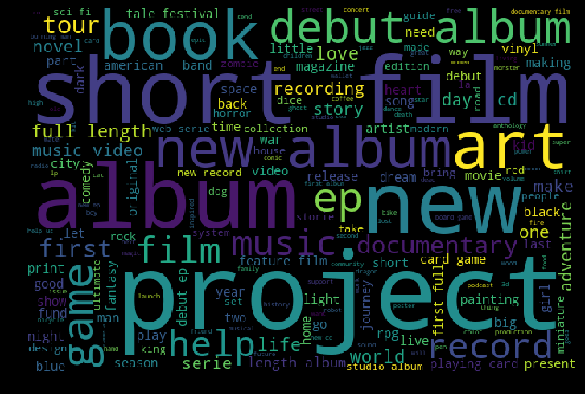

```python
#success word cloud
plt.figure(figsize=(10,8), facecolor='k')
plt.imshow(success_wordcloud)
plt.axis("off")
plt.tight_layout(pad=0)
plt.show()
```

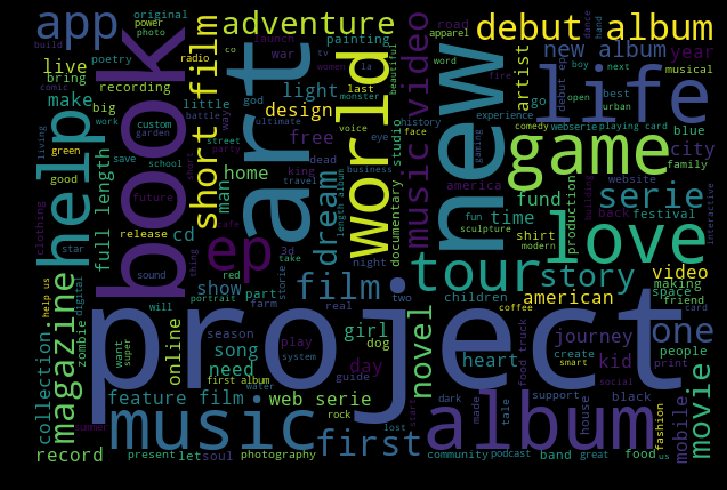

```python
#fail word cloud
plt.figure(figsize=(10,8), facecolor='k')
plt.imshow(fail_wordcloud)
plt.axis("off")
plt.tight_layout(pad=0)
plt.show()
```

The above figure is the word cloud of the keywords of successful projects; and the below figure shows the word cloud of the keywords of failed projects. So we can see that there's some underlying difference between them, which indicates that it's worthy to explore the textual features underlying the keywords, and probably description data as well.

## 2.2 Description word distribution visualization

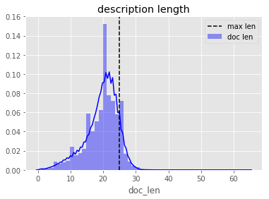

```python
# visualize word distribution in the training data set:
train['doc_len']=train['desc'].apply(lambda words: len(words.split(" ")))
max_seq_len = np.round(train['doc_len'].mean() + train['doc_len'].std()).astype(int)
sns.distplot(train['doc_len'], hist=True, kde=True, color='b', label='doc len')
plt.axvline(x=max_seq_len, color='k', linestyle='--', label='max len')
plt.title('description length'); plt.legend()
plt.show()
```

# 3. Pre-trained Word Embedding

### Keras CNN with FastText Embeddings

```python
import numpy as np
import pandas as pd
import seaborn as sns
import matplotlib.pyplot as plt

import keras
from keras import optimizers
from keras import backend as K
from keras import regularizers
from keras.models import Sequential
from keras.layers import Dense, Activation, Dropout, Flatten
from keras.layers import Embedding, Conv1D, MaxPooling1D, GlobalMaxPooling1D
from keras.utils import plot_model
from keras.preprocessing import sequence
from keras.preprocessing.text import Tokenizer
from keras.callbacks import EarlyStopping

from tqdm import tqdm
from nltk.corpus import stopwords
from nltk.tokenize import RegexpTokenizer
import os, re, csv, math, codecs

sns.set_style("whitegrid")

MAX_NB_WORDS = 100000
tokenizer = RegexpTokenizer(r'\w+')
stop_words = set(stopwords.words('english'))
stop_words.update(['.', ',', '"', "'", ':', ';', '(', ')', '[', ']', '{', '}'])

from subprocess import check_output
```

Load embeddings

```python
#load embeddings
print('loading word embeddings...')
embeddings_index = {}

f = codecs.open('wiki.simple.vec', encoding='utf-8')

for line in tqdm(f):
    values = line.rstrip().rsplit(' ')
    word = values[0]
    coefs = np.asarray(values[1:], dtype='float32')
    embeddings_index[word] = coefs
f.close()
print('found %s word vectors' % len(embeddings_index))
```

```
875it [00:00, 8746.59it/s]
```

```
loading word embeddings...
```

```
111052it [00:13, 8327.03it/s]
```

```
found 111052 word vectors
```

```python
y_train = train['final_status'].values
raw_doc_train=train['desc'].tolist()
raw_doc_test=test['desc'].tolist()
```

Preprocessing training and test data

```python
print("pre-processing training data")

processed_docs_train=[]
for doc in tqdm(raw_doc_train):
    # remove HTML
    doc = BeautifulSoup(doc).get_text()

    tokens=tokenizer.tokenize(doc)

    # remove remaining tokens that are not alphabetic
    tokens = [word for word in tokens if word.isalpha()]

    # filter out stop words
    tokens=[w for w in tokens if not w in stop_words]

    # filter out short tokens
    filtered=[word for word in tokens if len(word) > 1]

    processed_docs_train.append(" ".join(filtered))
```

[output not shown]

```
pre-processing training data
```

[output not shown]

```python
print("pre-processing test data")

processed_docs_test=[]
for doc in tqdm(raw_doc_test):
     # remove HTML
    doc = BeautifulSoup(doc).get_text()

    tokens=tokenizer.tokenize(doc)

    # remove remaining tokens that are not alphabetic
    tokens = [word for word in tokens if word.isalpha()]

    # filter out stop words
    tokens=[w for w in tokens if not w in stop_words]

    # filter out short tokens
    filtered=[word for word in tokens if len(word) > 1]

    processed_docs_test.append(" ".join(filtered))
```

[output not shown]

```
pre-processing test data
```

```python
print("tokenizing input data...")
tokenizer = Tokenizer(num_words=MAX_NB_WORDS, lower=True, char_level=False)
tokenizer.fit_on_texts(processed_docs_train + processed_docs_test)  #leaky
word_seq_train = tokenizer.texts_to_sequences(processed_docs_train)
word_seq_test = tokenizer.texts_to_sequences(processed_docs_test)
word_index = tokenizer.word_index
print("dictionary size: ", len(word_index))
```

```
tokenizing input data...
dictionary size:  67048
```

```python
#pad sequences
word_seq_train = sequence.pad_sequences(word_seq_train, maxlen=max_seq_len)
word_seq_test = sequence.pad_sequences(word_seq_test, maxlen=max_seq_len)
```

Define the training and model hyper-parameters:

```python
#training params
batch_size = 256
num_epochs = 8

#model parameters
num_filters = 64
embed_dim = 300
weight_decay = 1e-4
```

Prepare our embedding matrix limiting to a max number of words:

```python
#embedding matrix
print('preparing embedding matrix...')
words_not_found = []
nb_words = min(MAX_NB_WORDS, len(word_index))
embedding_matrix = np.zeros((nb_words+1, embed_dim))
for word, i in word_index.items():
    if i >= nb_words:
        continue
    embedding_vector = embeddings_index.get(word)
    if (embedding_vector is not None) and len(embedding_vector) > 0:
        # words not found in embedding index will be all-zeros.
        embedding_matrix[i] = embedding_vector
    else:
        words_not_found.append(word)
print('number of null word embeddings: %d' % np.sum(np.sum(embedding_matrix, axis=1) == 0))
```

```
preparing embedding matrix...
number of null word embeddings: 29655
```

look at the words not found in the embeddings:

```python
print("sample words not found: ", np.random.choice(words_not_found, 10))
```

```
sample words not found:  ['orahs' 'mouthfeel' 'noahpoptv' 'armtrade' 'brommobiel' 'krystle' 'pryvy'
 'estefani' 'exsoteric' 'scantlen']
```

CNN architecture:

```python
#CNN architecture
print("training CNN ...")
model = Sequential()
model.add(Embedding(nb_words + 1, embed_dim,
          weights=[embedding_matrix], input_length=max_seq_len, trainable=False))
model.add(Conv1D(num_filters, 7, activation='relu', padding='same'))
model.add(MaxPooling1D(2))
model.add(Conv1D(num_filters, 7, activation='relu', padding='same'))
model.add(GlobalMaxPooling1D())
model.add(Dropout(0.5))
model.add(Dense(32, activation='relu', kernel_regularizer=regularizers.l2(weight_decay)))
#1 label
model.add(Dense(1, activation='sigmoid'))  #multi-label (k-hot encoding)
adam = optimizers.Adam(lr=0.001, beta_1=0.9, beta_2=0.999, epsilon=1e-08, decay=0.0)
model.compile(loss='binary_crossentropy', optimizer=adam, metrics=['accuracy'])
model.summary()
```

```
training CNN ...
_________________________________________________________________
Layer (type)                 Output Shape              Param #
=================================================================
embedding_3 (Embedding)      (None, 25, 300)           20114700
_________________________________________________________________
conv1d_5 (Conv1D)            (None, 25, 64)            134464
_________________________________________________________________
max_pooling1d_3 (MaxPooling1 (None, 12, 64)            0
_________________________________________________________________
conv1d_6 (Conv1D)            (None, 12, 64)            28736
_________________________________________________________________
global_max_pooling1d_3 (Glob (None, 64)                0
_________________________________________________________________
dropout_3 (Dropout)          (None, 64)                0
_________________________________________________________________
dense_5 (Dense)              (None, 32)                2080
_________________________________________________________________
dense_6 (Dense)              (None, 1)                 33
=================================================================
Total params: 20,280,013
Trainable params: 165,313
Non-trainable params: 20,114,700
_________________________________________________________________
```

```python
#define callbacks
early_stopping = EarlyStopping(monitor='val_loss', min_delta=0.01, patience=4, verbose=1)
callbacks_list = [early_stopping]
```

```python
#model training
y_train=train['final_status'].values
hist = model.fit(word_seq_train, y_train, batch_size=batch_size, epochs=num_epochs,
                 callbacks=callbacks_list, validation_split=0.05263158, shuffle=False, verbose=2)
```

```
Train on 97307 samples, validate on 5406 samples
 - 41s - loss: 0.6219 - acc: 0.6782 - val_loss: 0.5995 - val_acc: 0.6794
 - 40s - loss: 0.5991 - acc: 0.6823 - val_loss: 0.5921 - val_acc: 0.6833
 - 40s - loss: 0.5867 - acc: 0.6880 - val_loss: 0.5897 - val_acc: 0.6902
 - 40s - loss: 0.5709 - acc: 0.6965 - val_loss: 0.5914 - val_acc: 0.6894
 - 40s - loss: 0.5514 - acc: 0.7102 - val_loss: 0.6098 - val_acc: 0.6833
Epoch 00005: early stopping
```

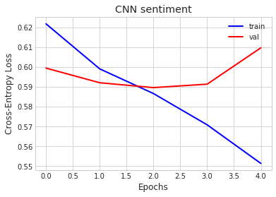

```python
#generate plots
plt.figure()
plt.plot(hist.history['loss'], lw=2.0, color='b', label='train')
plt.plot(hist.history['val_loss'], lw=2.0, color='r', label='val')
plt.title('CNN sentiment')
plt.xlabel('Epochs')
plt.ylabel('Cross-Entropy Loss')
plt.legend(loc='upper right')
plt.show()
```

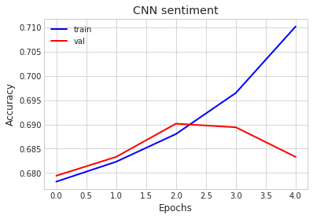

```python
plt.figure()
plt.plot(hist.history['acc'], lw=2.0, color='b', label='train')
plt.plot(hist.history['val_acc'], lw=2.0, color='r', label='val')
plt.title('CNN sentiment')
plt.xlabel('Epochs')
plt.ylabel('Accuracy')
plt.legend(loc='upper left')
plt.show()
```

see fitting loss and accuracy on development set:

```python
#According to the above model training process, we pick out the data used as the validate/dev set
word_seq_dev = word_seq_train[0:5405]
dev=train[0:5405]
```

```python
loss_dev, acc_dev = model.evaluate(word_seq_dev, dev['final_status'], verbose=0)
```

```python
print("dev loss: "+ str(loss))
print("dev accuracy: "+ str(acc))
```

[output not shown]

Make predictions on the test data

```python
loss, acc=model.evaluate(word_seq_test,test['final_status'],verbose=0)
```

```python
print("loss: "+ str(loss))
print("accuracy: "+ str(acc))
```

```
loss: 0.6103492513260399
accuracy: 0.6838697744350807
```

```python
data.columns.values
```

```
array(['project_id', 'name', 'desc', 'goal', 'keywords',
       'disable_communication', 'country', 'currency', 'deadline',
       'state_changed_at', 'created_at', 'launched_at', 'backers_count',
       'final_status'], dtype=object)
```

```python
data.head()
```

|  | project_id | name | desc | goal | keywords | disable_communication | country | currency | deadline | state_changed_at | created_at | launched_at | backers_count | final_status |
| --- | --- | --- | --- | --- | --- | --- | --- | --- | --- | --- | --- | --- | --- | --- |
| 0 | kkst1451568084 | drawing for dollars | I like drawing pictures. and then i color them... | 20.0 | drawing-for-dollars | False | US | USD | 1241333999 | 1241334017 | 1240600507 | 1240602723 | 3 | 1 |
| 1 | kkst1474482071 | Sponsor Dereck Blackburn (Lostwars) Artist in ... | I, Dereck Blackburn will be taking upon an inc... | 300.0 | sponsor-dereck-blackburn-lostwars-artist-in-re... | False | US | USD | 1242429000 | 1242432018 | 1240960224 | 1240975592 | 2 | 0 |
| 2 | kkst183622197 | Mr. Squiggles | So I saw darkpony's successfully funded drawin... | 30.0 | mr-squiggles | False | US | USD | 1243027560 | 1243027818 | 1242163613 | 1242164398 | 0 | 0 |
| 3 | kkst597742710 | Help me write my second novel. | Do your part to help out starving artists and ... | 500.0 | help-me-write-my-second-novel | False | US | USD | 1243555740 | 1243556121 | 1240963795 | 1240966730 | 18 | 1 |
| 4 | kkst1913131122 | Support casting my sculpture in bronze | I'm nearing completion on a sculpture, current... | 2000.0 | support-casting-my-sculpture-in-bronze | False | US | USD | 1243769880 | 1243770317 | 1241177914 | 1241180541 | 1 | 0 |

So my intuition and common sense tells that the final status can be dependent on how long the project is allowed, how much money is aimed for whether communication is disbled, also maybe dependent on the country and currency. Since the money in different country uses different currency, so what I want to do is that first transform the money into the scale of US Dollar.

In addition, the final status can also probably depend on the keyword/description of the project, which are text features.

Now look at the values for the categorical variables.

```python
data.disable_communication.unique()
```

```
array([False,  True])
```

```python
data.currency.unique()
```

```
array(['USD', 'GBP', 'CAD', 'AUD', 'NZD', 'EUR', 'SEK', 'NOK', 'DKK'],
      dtype=object)
```

```python
data_curr_tran=data
```

```python
data_curr_tran[data_curr_tran['currency']=='GBP']['goal']=1.33*data[data['currency']=='GBP']['goal']
data_curr_tran[data_curr_tran['currency']=='CAD']['goal']=1.33*data[data['currency']=='CAD']['goal']
data_curr_tran[data_curr_tran['currency']=='AUD']['goal']=1.33*data[data['currency']=='AUD']['goal']
data_curr_tran[data_curr_tran['currency']=='NZD']['goal']=1.33*data[data['currency']=='NZD']['goal']
data_curr_tran[data_curr_tran['currency']=='EUR']['goal']=1.33*data[data['currency']=='EUR']['goal']
data_curr_tran[data_curr_tran['currency']=='SEK']['goal']=1.33*data[data['currency']=='SEK']['goal']
data_curr_tran[data_curr_tran['currency']=='NOK']['goal']=1.33*data[data['currency']=='NOK']['goal']
data_curr_tran[data_curr_tran['currency']=='DKK']['goal']=1.33*data[data['currency']=='DKK']['goal']
```

[output not shown]

```python
newdata=data_curr_tran.drop('currency',1) #drop the currency column
```

```python
no_backers=newdata[newdata['backers_count']==0]
```

```python
no_backers.shape
```

```
(12829, 13)
```

```python
abnormal=no_backers[no_backers['final_status']==1]
abnormal.shape
```

```
(0, 13)
```

So this corresponds to our common sense that if there's no backer, then the final status should be 0, which means the project should fail. So we can actually remove these columns.

```python
data_back=newdata[newdata['backers_count']!=0]
```

```python
data_back.shape
```

```
(95290, 13)
```

```python
print("maximum goal in data_back: " + str(np.max(data_back['goal'])))
print("minimum goal in data_back: " + str(np.min(data_back['goal'])))
```

```
maximum goal in data_back: 100000000.0
minimum goal in data_back: 0.01
```

```python
print("median of the goal in data_back: "+ str(np.median(data_back['goal'])))
```

```
median of the goal in data_back: 5000.0
```

```python
print("maximum goal in no_backer: " + str(np.max(no_backers['goal'])))
print("minimum goal in no_backer: " + str(np.min(no_backers['goal'])))
```

```
maximum goal in no_backer: 100000000.0
minimum goal in no_backer: 1.0
```

```python
print("median of the goal in no_backer: "+ str(np.median(no_backers['goal'])))
```

```
median of the goal in no_backer: 5000.0
```

Now we may look at the projects in different countries

```python
data.country.unique()
```

```
array(['US', 'GB', 'CA', 'AU', 'NZ', 'NL', 'SE', 'IE', 'NO', 'DK', 'DE'],
      dtype=object)
```

Make a boxplot to see the goal of the money in different countries

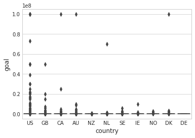

```python
sns.set_style("whitegrid")
ax=sns.boxplot(x="country",y="goal",data=newdata)
```

We may zoom in to look at the projects with smaller amount of money goals:

```python
data_smaller=newdata[newdata['goal']<0.25*1e7]
```

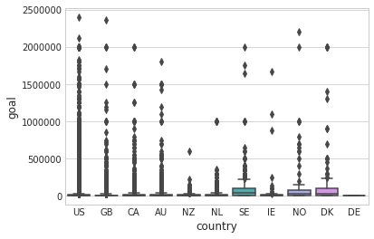

```python
sns.set_style("whitegrid")
ax=sns.boxplot(x="country",y="goal",data=data_smaller)
```

Similary, we may also look at the goal with respect to the number of backers

```python
newdata['with_backers']=(newdata['backers_count']>0).astype('int')
```

```python
newdata.head()
```

|  | project_id | name | desc | goal | keywords | disable_communication | country | deadline | state_changed_at | created_at | launched_at | backers_count | final_status | with_backers |
| --- | --- | --- | --- | --- | --- | --- | --- | --- | --- | --- | --- | --- | --- | --- |
| 0 | kkst1451568084 | drawing for dollars | I like drawing pictures. and then i color them... | 20.0 | drawing-for-dollars | False | US | 1241333999 | 1241334017 | 1240600507 | 1240602723 | 3 | 1 | 1 |
| 1 | kkst1474482071 | Sponsor Dereck Blackburn (Lostwars) Artist in ... | I, Dereck Blackburn will be taking upon an inc... | 300.0 | sponsor-dereck-blackburn-lostwars-artist-in-re... | False | US | 1242429000 | 1242432018 | 1240960224 | 1240975592 | 2 | 0 | 1 |
| 2 | kkst183622197 | Mr. Squiggles | So I saw darkpony's successfully funded drawin... | 30.0 | mr-squiggles | False | US | 1243027560 | 1243027818 | 1242163613 | 1242164398 | 0 | 0 | 0 |
| 3 | kkst597742710 | Help me write my second novel. | Do your part to help out starving artists and ... | 500.0 | help-me-write-my-second-novel | False | US | 1243555740 | 1243556121 | 1240963795 | 1240966730 | 18 | 1 | 1 |
| 4 | kkst1913131122 | Support casting my sculpture in bronze | I'm nearing completion on a sculpture, current... | 2000.0 | support-casting-my-sculpture-in-bronze | False | US | 1243769880 | 1243770317 | 1241177914 | 1241180541 | 1 | 0 | 1 |

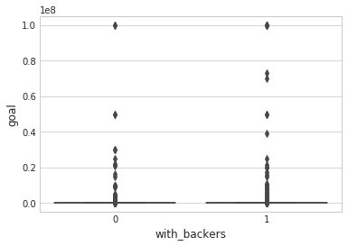

```python
sns.set_style("whitegrid")
ax=sns.boxplot(x="with_backers",y="goal",data=newdata)
```

zoom in

```python
data_smaller=newdata[newdata['goal']<0.25*1e7]
```

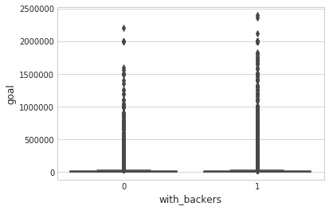

```python
sns.set_style("whitegrid")
ax=sns.boxplot(x="with_backers",y="goal",data=data_smaller)
```

Now we want to add a column which records the number of days of each project:

```python
data_back['launched_at']=data_back['launched_at'].astype('int')
data_back['deadline']=data_back['deadline'].astype('int')
```

```python
time=(data_back['deadline']-data_back['launched_at'])/(3600*24)
data_back['days']=time #number of days of this project
```

```python
data_back.head()
```

|  | project_id | name | desc | goal | keywords | disable_communication | country | deadline | state_changed_at | created_at | launched_at | backers_count | final_status | days |
| --- | --- | --- | --- | --- | --- | --- | --- | --- | --- | --- | --- | --- | --- | --- |
| 0 | kkst1451568084 | drawing for dollars | I like drawing pictures. and then i color them... | 20.0 | drawing-for-dollars | False | US | 1241333999 | 1241334017 | 1240600507 | 1240602723 | 3 | 1 | 8.463843 |
| 1 | kkst1474482071 | Sponsor Dereck Blackburn (Lostwars) Artist in ... | I, Dereck Blackburn will be taking upon an inc... | 300.0 | sponsor-dereck-blackburn-lostwars-artist-in-re... | False | US | 1242429000 | 1242432018 | 1240960224 | 1240975592 | 2 | 0 | 16.821852 |
| 3 | kkst597742710 | Help me write my second novel. | Do your part to help out starving artists and ... | 500.0 | help-me-write-my-second-novel | False | US | 1243555740 | 1243556121 | 1240963795 | 1240966730 | 18 | 1 | 29.965394 |
| 4 | kkst1913131122 | Support casting my sculpture in bronze | I'm nearing completion on a sculpture, current... | 2000.0 | support-casting-my-sculpture-in-bronze | False | US | 1243769880 | 1243770317 | 1241177914 | 1241180541 | 1 | 0 | 29.969201 |
| 5 | kkst1085176748 | daily digest | I'm a fledgling videoblogger living in Brookly... | 700.0 | daily-digest | False | US | 1243815600 | 1243816219 | 1241050799 | 1241464468 | 14 | 0 | 27.212176 |

**Visualize the relationship between final status and country**

```python
country=data_back['country'].astype('category')
final_status=data_back['final_status'].astype('category')
```

```python
country_pd=pd.DataFrame(country)
status_pd=pd.DataFrame(final_status)
country_status_pd=pd.concat([country_pd,status_pd],axis=1)
```

For the whole data set (including the rows without any backer (backer_count=0))

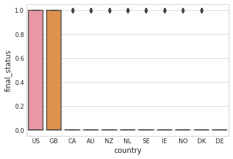

```python
sns.set_style("whitegrid")
ax=sns.boxplot(x="country",y="final_status",data=newdata)
```

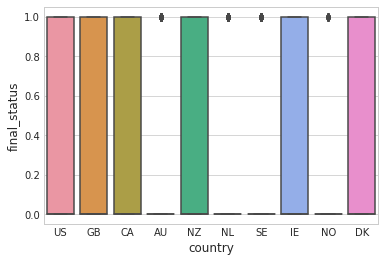

```python
sns.set_style("whitegrid")
ax=sns.boxplot(x="country",y="final_status",data=data_back)
```

Seems there's something going on with respect to the country variable. Look at the final status within each country. Let's first look at AU, NL, SE, NO

```
Text(0.5,1,'NO')
```

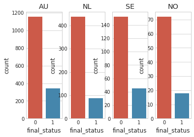

```python
fig, axs = plt.subplots(ncols=4)

AU_back=data_back[data_back['country']=='AU']
sns.countplot(AU_back['final_status'],ax=axs[0]).set_title('AU')

NL_back=data_back[data_back['country']=='NL']
sns.countplot(NL_back['final_status'],ax=axs[1]).set_title('NL')

SE_back=data_back[data_back['country']=='SE']
sns.countplot(SE_back['final_status'],ax=axs[2]).set_title('SE')

NO_back=data_back[data_back['country']=='NO']
sns.countplot(NO_back['final_status'],ax=axs[3]).set_title('NO')
```

Then US, GB, CA, NZ, IE, DK

```
Text(0.5,1,'DK')
```

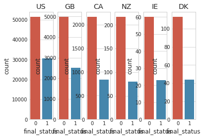

```python
fig, axs = plt.subplots(ncols=6)

US_back=data_back[data_back['country']=='US']
sns.countplot(US_back['final_status'],ax=axs[0]).set_title('US')

GB_back=data_back[data_back['country']=='GB']
sns.countplot(GB_back['final_status'],ax=axs[1]).set_title('GB')

CA_back=data_back[data_back['country']=='CA']
sns.countplot(CA_back['final_status'],ax=axs[2]).set_title('CA')

NZ_back=data_back[data_back['country']=='NZ']
sns.countplot(NZ_back['final_status'],ax=axs[3]).set_title('NZ')

IE_back=data_back[data_back['country']=='IE']
sns.countplot(IE_back['final_status'],ax=axs[4]).set_title('IE')

DK_back=data_back[data_back['country']=='DK']
sns.countplot(DK_back['final_status'],ax=axs[5]).set_title('DK')
```

```
US backed projects shape: (81957, 14)
all backed projects shape: (95290, 14)
```

```
Text(0.5,1,'country count')
```

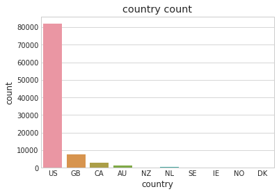

```python
print("US backed projects shape: "+str(US_back.shape))
print("all backed projects shape: "+ str(data_back.shape))
sns.countplot(data_back['country']).set_title('country count')
```

**Look at non-US countries:**

```python
nonUS_back=data_back[data_back['country']!='US']
nonUS_back.shape
```

```
(13333, 14)
```

```
Text(0.5,1,'country count')
```

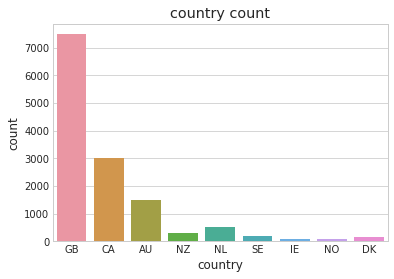

```python
sns.countplot(nonUS_back['country']).set_title('country count')
```

# 5. Model training

Obviously, the projects in the US takes a significant part in the total sample. Maybe we can take US out separately and combine the other countries in our model training.

For prediction of the success with column 'backers_count', we can first train our model on the data sets whose backer_count are non zero, later we can include the information with those whose backer_count number are zero.

Let's first train our model on US backed data.

```python
US_back.head()
```

|  | project_id | name | desc | goal | keywords | disable_communication | country | deadline | state_changed_at | created_at | launched_at | backers_count | final_status | days |
| --- | --- | --- | --- | --- | --- | --- | --- | --- | --- | --- | --- | --- | --- | --- |
| 0 | kkst1451568084 | drawing for dollars | I like drawing pictures. and then i color them... | 20.0 | drawing-for-dollars | False | US | 1241333999 | 1241334017 | 1240600507 | 1240602723 | 3 | 1 | 8.463843 |
| 1 | kkst1474482071 | Sponsor Dereck Blackburn (Lostwars) Artist in ... | I, Dereck Blackburn will be taking upon an inc... | 300.0 | sponsor-dereck-blackburn-lostwars-artist-in-re... | False | US | 1242429000 | 1242432018 | 1240960224 | 1240975592 | 2 | 0 | 16.821852 |
| 3 | kkst597742710 | Help me write my second novel. | Do your part to help out starving artists and ... | 500.0 | help-me-write-my-second-novel | False | US | 1243555740 | 1243556121 | 1240963795 | 1240966730 | 18 | 1 | 29.965394 |
| 4 | kkst1913131122 | Support casting my sculpture in bronze | I'm nearing completion on a sculpture, current... | 2000.0 | support-casting-my-sculpture-in-bronze | False | US | 1243769880 | 1243770317 | 1241177914 | 1241180541 | 1 | 0 | 29.969201 |
| 5 | kkst1085176748 | daily digest | I'm a fledgling videoblogger living in Brookly... | 700.0 | daily-digest | False | US | 1243815600 | 1243816219 | 1241050799 | 1241464468 | 14 | 0 | 27.212176 |

```
Text(0.5,1,'disable_communication')
```

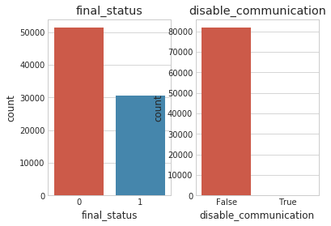

```python
fig,axs = plt.subplots(ncols=2)
sns.countplot(US_back['final_status'],ax=axs[0]).set_title('final_status')
sns.countplot(US_back['disable_communication'],ax=axs[1]).set_title('disable_communication')
```

```python
US_back.disable_communication.unique()
US_back_disable=US_back[US_back['disable_communication']==True]
print("US_back_disable.shape: "+str(US_back_disable.shape))
print("US_back_disable successful project size: "
      +str(US_back_disable[US_back_disable['final_status']==1].shape))
```

```
US_back_disable.shape: (137, 14)
US_back_disable successful project size: (0, 14)
```

No project succeeded in US if they disable their communication in the process.

But how about the whole data set, is this the case for every project?

```python
data_back_disable=data_back[data_back['disable_communication']==True]
print("data_back_disable successful project size: "
      +str(data_back_disable[data_back_disable['final_status']==1].shape))
```

```
data_back_disable successful project size: (0, 14)
```

Again, we find that if the communication is disabled in the middle, then no successful project!

So now we just train our model for US countries, those who are backed and didn't disable communication in the middle.

```python
# only look at those who didn't disable communication
US_back_nodis=US_back[US_back['disable_communication']==False]
```

```python
US_back_nodis.shape # sample size of the US data set we look at
```

```
(81820, 14)
```

```python
# and we can actually just throw away the disable_communication column
US_back_nodis=US_back_nodis.drop('disable_communication',1)
```

```python
US_back_nodis.head()
```

|  | project_id | name | desc | goal | keywords | country | deadline | state_changed_at | created_at | launched_at | backers_count | final_status | days |
| --- | --- | --- | --- | --- | --- | --- | --- | --- | --- | --- | --- | --- | --- |
| 0 | kkst1451568084 | drawing for dollars | I like drawing pictures. and then i color them... | 20.0 | drawing-for-dollars | US | 1241333999 | 1241334017 | 1240600507 | 1240602723 | 3 | 1 | 8.463843 |
| 1 | kkst1474482071 | Sponsor Dereck Blackburn (Lostwars) Artist in ... | I, Dereck Blackburn will be taking upon an inc... | 300.0 | sponsor-dereck-blackburn-lostwars-artist-in-re... | US | 1242429000 | 1242432018 | 1240960224 | 1240975592 | 2 | 0 | 16.821852 |
| 3 | kkst597742710 | Help me write my second novel. | Do your part to help out starving artists and ... | 500.0 | help-me-write-my-second-novel | US | 1243555740 | 1243556121 | 1240963795 | 1240966730 | 18 | 1 | 29.965394 |
| 4 | kkst1913131122 | Support casting my sculpture in bronze | I'm nearing completion on a sculpture, current... | 2000.0 | support-casting-my-sculpture-in-bronze | US | 1243769880 | 1243770317 | 1241177914 | 1241180541 | 1 | 0 | 29.969201 |
| 5 | kkst1085176748 | daily digest | I'm a fledgling videoblogger living in Brookly... | 700.0 | daily-digest | US | 1243815600 | 1243816219 | 1241050799 | 1241464468 | 14 | 0 | 27.212176 |

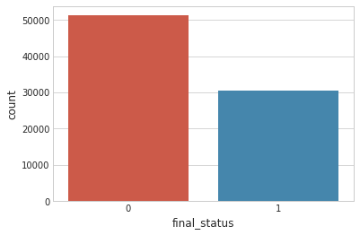

```python
#count plot of US_back_nodis
sns.countplot(US_back_nodis['final_status'])
```

```python
# ratio of successful project that we look at
US_back_nodis[US_back_nodis['final_status']==1].shape[0]/US_back_nodis.shape[0]
```

```
0.3736616964067465
```

So about 37.4% are successful projects.

```python
# split the data into 90/5/5
# Since later in model training, we'll do validation split, so we'll split the data set as 95/5
## the dev set will be automatically included in the training proces
from sklearn.model_selection import train_test_split
US_train_dev,US_test=train_test_split(US_back_nodis,test_size=0.05, random_state=10)
print("US_train and dev set: "+str(US_train_dev.shape))
print("US_test: "+ str(US_test.shape))
```

```
US_train and dev set: (77729, 13)
US_test: (4091, 13)
```

```python
US_train, US_dev=train_test_split(US_train_dev,test_size=5/95,random_state=10)
print("US_train size: " + str(US_train.shape))
print("US_dev size: " + str(US_dev.shape))
```

```
US_train size: (73638, 13)
US_dev size: (4091, 13)
```

Numeric variables that we want to use: goal, time, backers count.

## Baseline Models on US data seet

First want to train our model just using these 3 numerical variables. Before using Neural Network, we may try to look at some baseline models.

**1.Random Forest**

```python
from sklearn.ensemble import RandomForestClassifier
```

```python
rf = RandomForestClassifier(max_depth=13, random_state=0)
rf.fit(US_train[['goal','backers_count','days']],US_train['final_status'])
```

```
RandomForestClassifier(bootstrap=True, class_weight=None, criterion='gini',
            max_depth=13, max_features='auto', max_leaf_nodes=None,
            min_impurity_decrease=0.0, min_impurity_split=None,
            min_samples_leaf=1, min_samples_split=2,
            min_weight_fraction_leaf=0.0, n_estimators=10, n_jobs=1,
            oob_score=False, random_state=0, verbose=0, warm_start=False)
```

```python
#feature importance for goal, backer_count, days respectively
print(rf.feature_importances_)
```

```
[0.19883852 0.72933993 0.07182155]
```

```python
# prediction for dev set
status_pred_dev=rf.predict(US_dev[['goal','backers_count','days']])
# prediction for test set
status_pred_test=rf.predict(US_test[['goal','backers_count','days']])
```

```python
# Create confusion matrix for test set
pd.crosstab(US_dev['final_status'], status_pred_dev,
            rownames=['Actual status'], colnames=['Predicted status'])
```

| Predicted status Actual status | 0 | 1 |
| --- | --- | --- |
| 0 | 2233 | 351 |
| 1 | 248 | 1259 |

```python
# Create confusion matrix for test set
pd.crosstab(US_test['final_status'], status_pred_test,
            rownames=['Actual status'], colnames=['Predicted status'])
```

| Predicted status Actual status | 0 | 1 |
| --- | --- | --- |
| 0 | 2213 | 388 |
| 1 | 230 | 1260 |

```python
from sklearn.metrics import accuracy_score
# classification accuracy for dev set
dev_accuracy=accuracy_score(US_dev['final_status'],status_pred_dev)
print("dev accuracy: "+ str(dev_accuracy))
# classification accuracy for test set
test_accuracy=accuracy_score(US_test['final_status'], status_pred_test)
print("test accuracy: "+ str(test_accuracy))
```

```
dev accuracy: 0.8535810315326327
test accuracy: 0.8489366902957712
```

**2. Logisitc regression**

```python
from sklearn.linear_model import LogisticRegression
clf=LogisticRegression()
```

```python
clf.fit(US_train[['goal','backers_count','days']],US_train['final_status'])
log_pred_dev=clf.predict(US_dev[['goal','backers_count','days']])
log_pred_test=clf.predict(US_test[['goal','backers_count','days']])
```

```python
# Create confusion matrix for dev set
pd.crosstab(US_dev['final_status'], log_pred_dev,
            rownames=['Actual status'], colnames=['Predicted status for dev set'])
```

| Predicted status for dev set Actual status | 0 | 1 |
| --- | --- | --- |
| 0 | 2392 | 192 |
| 1 | 554 | 953 |

```python
score_dev = clf.score(US_dev[['goal','backers_count','days']],
                  US_dev['final_status'])
#dev set accuracy of logistic regression
print("dev set accuracy: "+str(score_dev))
```

```
dev set accuracy: 0.8176484967000733
```

```python
# Create confusion matrix for dev set
pd.crosstab(US_dev['final_status'], log_pred_dev,
            rownames=['Actual status'], colnames=['Predicted status for dev set'])
```

| Predicted status for dev set Actual status | 0 | 1 |
| --- | --- | --- |
| 0 | 2392 | 192 |
| 1 | 554 | 953 |

```python
score_test = clf.score(US_test[['goal','backers_count','days']],
                  US_test['final_status'])
#accuracy of logistic regression
print("test set accuracy: "+str(score_test))
```

```
test set accuracy: 0.8232705939868002
```

```python
# Create confusion matrix for dev set
pd.crosstab(US_test['final_status'], log_pred_test,
            rownames=['Actual status'],
            colnames=['Predicted status for dev set'])
```

| Predicted status for dev set Actual status | 0 | 1 |
| --- | --- | --- |
| 0 | 2379 | 222 |
| 1 | 501 | 989 |

### 3. Neural Network

First train our model without using the text features. So still, we look at the numerical variables: goal, backers_count, days.

```python
#training
X_train_US = US_train[['goal','backers_count','days']]
Y_train_US = US_train[['final_status']]
X_train_US=X_train_US.as_matrix()
Y_train_US=Y_train_US.as_matrix()

# dev
X_dev_US = US_dev[['goal','backers_count','days']]
Y_dev_US = US_dev[['final_status']]
X_dev_US=X_dev_US.as_matrix()
Y_dev_US=Y_dev_US.as_matrix()


# test
X_test_US = US_test[['goal','backers_count','days']]
Y_test_US = US_test[['final_status']]
X_test_US=X_test_US.as_matrix()
Y_test_US=Y_test_US.as_matrix()
```

```python
from keras.utils import to_categorical
from keras import models
from keras import layers
from keras.models import Sequential
from keras.layers import Dense, Activation, Dropout
```

Now start to train the neural networks: For each sample, we input 3 features: goal, backers_count, days

```python
model_1 = Sequential()
```

```python
# Input - Layer
model_1.add(Dense(5,activation="relu",
                  kernel_initializer='glorot_uniform',
                  input_shape=(3,)))

# Hidden - Layers
model_1.add(Dense(3,activation="relu"))
model_1.add(layers.Dropout(0.2,noise_shape=None, seed=0))
model_1.add(Dense(2,activation="relu"))

# Output - Layer
model_1.add(Dense(1, activation="sigmoid"))

model_1.summary()
```

```
_________________________________________________________________
Layer (type)                 Output Shape              Param #
=================================================================
dense_15 (Dense)             (None, 5)                 20
_________________________________________________________________
dense_16 (Dense)             (None, 3)                 18
_________________________________________________________________
dropout_4 (Dropout)          (None, 3)                 0
_________________________________________________________________
dense_17 (Dense)             (None, 2)                 8
_________________________________________________________________
dense_18 (Dense)             (None, 1)                 3
=================================================================
Total params: 49
Trainable params: 49
Non-trainable params: 0
_________________________________________________________________
```

```python
model_1.compile(optimizer='rmsprop',
               loss='binary_crossentropy',
               metrics=['accuracy'])
```

```python
mode1_fit_1=model_1.fit(X_train_US, Y_train_US,
          batch_size=64, epochs=100,
         validation_data=(X_dev_US, Y_dev_US))
```

```
Train on 73638 samples, validate on 4091 samples
```

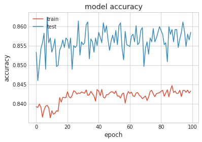

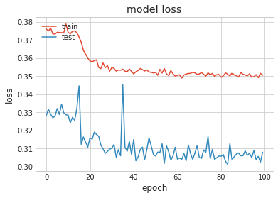

```python
# summarize history for accuracy
plt.plot(mode1_fit_1.history['acc'])
plt.plot(mode1_fit_1.history['val_acc'])
plt.title('model accuracy')
plt.ylabel('accuracy')
plt.xlabel('epoch')
plt.legend(['train', 'test'], loc='upper left')
plt.show()
# summarize history for loss
plt.plot(mode1_fit_1.history['loss'])
plt.plot(mode1_fit_1.history['val_loss'])
plt.title('model loss')
plt.ylabel('loss')
plt.xlabel('epoch')
plt.legend(['train', 'test'], loc='upper left')
plt.show()
```

```python
# make a prediction on the test data set
US_test_pred = model_1.predict_classes(X_test_US)
temp = sum(US_test_pred == Y_test_US)
accuracy=temp/len(Y_test_US)
print("test data accuracy: "+ str(accuracy[0]))
```

```
test data accuracy: 0.855047665607431
```